# Prosper Loan Data Exploration

## 1. Introduction

This document explores a dataset of 84672 rows and 23 columns of loan data. It is worthy to note that this is a subset of the original dataset which contains 113937 entries, 81 columns.

## 2. Univariate Exploration

> 1. What loan term has the highest count?

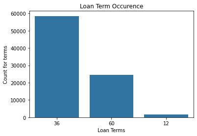

Most borrowers take the loan for a period of 36 months as shown above.

> 1. How did prosper rate their borrowers from HR(High Risk) to AA(Excellence)?

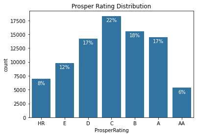

From the above chat going from the lowest(HR) to AA(considered the best), we see that 22% of the borrowers were merely rated average(C). There's an even distribution of the borrowers on both sides from low to high.

> 1. How is the Original loan amount distributed? what range has a higher occurrence?

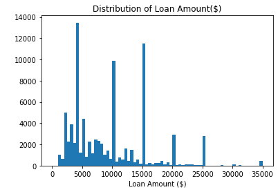

Now we see that the major peaks are around 4,000, 10,000 and 15,000 which represent mostly occuring loan amounts.

> 1. Who are Prosper's clients? what are their income range?

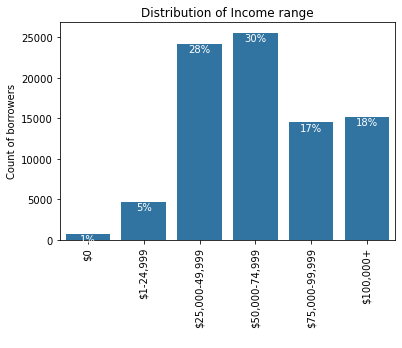

## 3. Bivariate Exploration

- How does being a homeowner, affect a borrower's rating?
- What is the distribution of home owners across the income ranges?

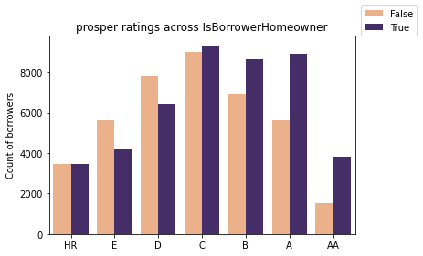

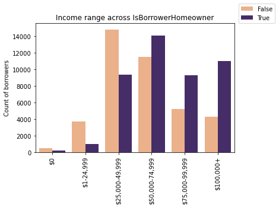

- Ofcourse, borrowers who own their homes got higher ratings than those who didn't.
- Those who own thier homes were seen to be those whose range were a bit higher as compared to those who weren't home owners.

Explore prosper score vs Loan Original Amount across Terms

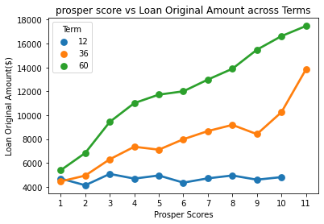

## 4. Multivariate Exploration

- What impact does owning a home and having a high score have on the loan amount?
- Explore genrally the relationship between variables.

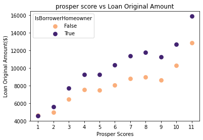

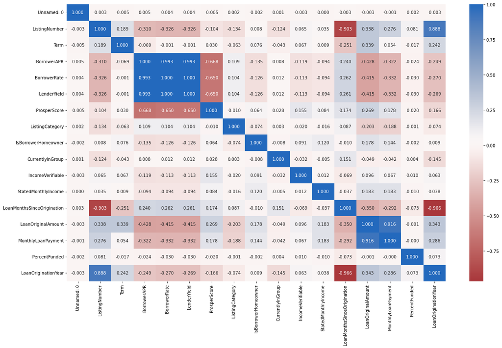

Next, The relationship strong positive correlation between Loan Amoount and Monthly loan payment.